# Projet ML01 - ML01 Project

## Comment détecter les requêtes web malveillantes pour protéger une application web ?

## How to detect malicious web requests to protect a web application?

### Objectif :

Le projet à pour but de s'initier aux principes du machine learning et à travers ce notebook, nous cherchons à appliquer les différents classifieurs étudiés en cours sur un dataset dont le choix est laissé aux étudiants. En ce qui nous concerne, le choix s'est porté sur *CSIC 2010 Web Application Attacks Classifier*, contenant des données de trafic ciblant une application web d'e-commerce, présentant des attaques XSS, SQLI, CSRF et autres anomalies. Il s'agit d'un dataset comprenant 36 000 requêtes normales et plus de 25 000 requêtes anormales (i.e des attaques web).

### Objective:

The purpose of this project is to familiarize ourselves with the principles of machine learning. Through this notebook, we aim to apply the different classifiers studied in class on a dataset, with the choice of the dataset being left to the students. In our case, we selected the CSIC 2010 Web Application Attacks Classifier, which contains traffic data targeting an e-commerce web application and includes XSS, SQLI, CSRF, and other anomalies. This dataset consists of 36,000 normal requests and over 25,000 anomalous requests (i.e., web attacks).

### La partie pré-traitement est reprise directement du notebook de [Gabriele Poddighe](https://www.kaggle.com/code/gabrielepoddighe/csic-2010-web-application-attacks-classifier/notebook)

#### Participants :

Mohamed El Ahmadi, Amira Rahmani, Sacha Bourguet, Gilles Deblieck, Yassine Ouzzane

## Import des bibliothèques - Importing the libraries

```python
# Imports des bibliothèques
import numpy as np
import pandas as pd
import seaborn as sns
%matplotlib inline
import matplotlib.pyplot as plt
from matplotlib.colors import ListedColormap
import re
import math
import graphviz
import warnings
from IPython.display import Image, display


# Imports pour scikit
import sklearn
from urllib.parse import urlparse
from sklearn.preprocessing import LabelEncoder
from sklearn.model_selection import train_test_split


# Imports pour les classifieurs
from sklearn.model_selection import train_test_split
from sklearn.manifold import TSNE
from sklearn.ensemble import RandomForestClassifier
from sklearn.metrics import precision_score
from sklearn.metrics import accuracy_score
from sklearn.metrics import recall_score
from sklearn.metrics import f1_score
from sklearn.metrics import roc_auc_score
from sklearn.metrics import roc_curve
from sklearn.metrics import auc
from sklearn.metrics import mean_absolute_error
from sklearn.metrics import confusion_matrix
from sklearn.metrics import classification_report
from sklearn.linear_model import SGDClassifier
from sklearn.svm import LinearSVC
from sklearn.svm import SVC
from sklearn.neighbors import KNeighborsClassifier
from sklearn.naive_bayes import GaussianNB
from sklearn.discriminant_analysis import LinearDiscriminantAnalysis
from sklearn.discriminant_analysis import QuadraticDiscriminantAnalysis
from sklearn.model_selection import GridSearchCV
from sklearn import tree
from sklearn.tree import DecisionTreeClassifier
from sklearn.linear_model import LogisticRegression
from sklearn.model_selection import StratifiedKFold
from sklearn.model_selection import KFold
from sklearn.neural_network import MLPClassifier
from sklearn.inspection import PartialDependenceDisplay
from sklearn.model_selection import train_test_split
from sklearn.metrics import accuracy_score, confusion_matrix, classification_report
```

## Import de la base de donnée et initialisation - Importing the dataset and initialization

```python
# Import de la base traitée
X = pd.read_csv('db_post_process.csv')

# Choix des variables discriminatives
labels = ['count_dot_url', 'count_dir_url', 'count_embed_domain_url', 'count-http',
                'count%_url', 'count?_url', 'count-_url', 'count=_url', 'url_length', 'hostname_length_url',
                'sus_url', 'count-digits_url', 'count-letters_url', 'number_of_parameters_url',
                'is_encoded_url','special_count_url','unusual_character_ratio_url',
                 #method
                'Method_enc',
                #content
                'count_dot_content','count%_content',
                 'count-_content','count=_content','sus_content','count_digits_content',
                  'count_letters_content','content_length',
               'is_encoded_content','special_count_content']

#print(X[labels])
#print(X)

y = X['classification']
#print(y)

X_train, X_test, y_train, y_test = train_test_split(X[labels], y, test_size=0.3, random_state=0)
```

## Analyse des données - Data Analysis

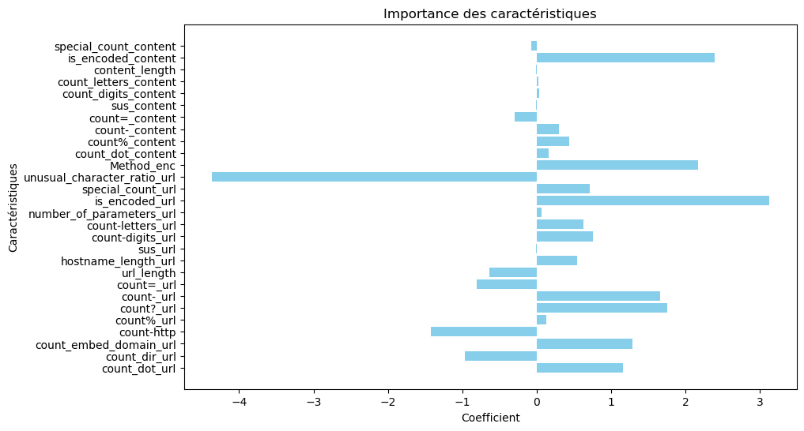

```python
warnings.filterwarnings("ignore")

model = LogisticRegression(max_iter=10000)
model.fit(X_train, y_train)
coefficients = model.coef_[0]
features = X_train.columns

plt.figure(figsize=(10, 6))
plt.barh(features, coefficients, color="skyblue")
plt.xlabel("Coefficient")
plt.ylabel("Caractéristiques")
plt.title("Importance des caractéristiques")
plt.show()
```

Ici, chaque barre représente une caractérisitque utilisée dans le modèle. En ordonnée ce sont nos caractéristiques et en abscisse un coefficient nous indiquant l'impact qu'à une des caractéristiques sur la prédiction de nos classes.

En valeur absolue, plus la valeur est importante et plus elle est "discriminante" pour notre modèle. Par exemple les variables `is_encoded_content`et `is_encoded_url` auront un impact important dans l'attribution des classes.

On remarque ici la variable `unusual_character_ratio_url`, c'est une variable qui détecte des caractères non habituels (?, &, =, #, etc.). Cette variable a un très gros score négatif, ce qui nous indique ici, que la présence de caractères inhabituels dans l'URL est associée à une probabilité plus faible d'appartenir à la classe positive.

Un autre exemple est la variable `Method_enc` a également un coefficient positif important, indiquant que la méthode utilisée sur la requête web est un facteur important dans la classification de celle-ci.

Here, each bar represents a feature used in the model. On the y-axis, we have our features, and on the x-axis, a coefficient indicating the impact of each feature on the prediction of our classes.

In absolute value, the higher the coefficient, the more "discriminative" the feature is for our model. For instance, the variables `is_encoded_content` and `is_encoded_url` will have a significant impact on the class assignment.

We can observe that the variable `unusual_character_ratio_url`, which detects unusual characters (such as ?, &, =, #, etc.), has a very negative score. This indicates that the presence of unusual characters in the URL is associated with a lower probability of belonging to the positive class.

Another example is the variable `Method_enc`, which also has a significant positive coefficient, indicating that the method used on the web request is an important factor in its classification.

### Distribution des variables

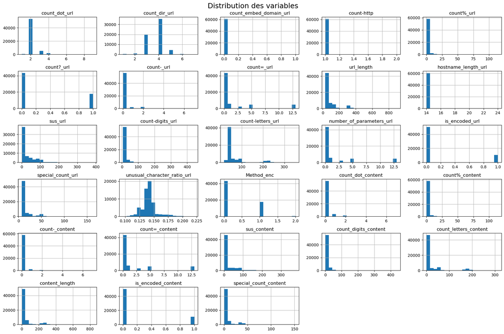

```python
X[labels].hist(figsize=(18, 12), bins=20)
plt.suptitle('Distribution des variables', fontsize=18)
plt.tight_layout()
plt.show()
```

Ce graphe montre la distribution des différentes variables utilisées dans notre modèle.

On remarque que certaines variables, comme `count_dot_url` et `count_dir_url`, montrent une distribution très concentrée autour de certaines valeurs, indiquant que ces valeurs sont fréquentes dans notre dataset.

D'autres variables ne prennent que deux valeurs (0 et 1), c'est le cas par exemple de la variable `is_encoded_url`, qui nous indique ici la présence de variables binaires.

This graph shows the distribution of the different variables used in our model.

We can see that some variables, like `count_dot_url` and `count_dir_url`, have a very concentrated distribution around certain values, indicating that these values are common in our dataset.

Additionally, some variables take only two values (0 and 1), such as the `is_encoded_url` variable, indicating the presence of binary features in the dataset.

### Matrice de corrélation

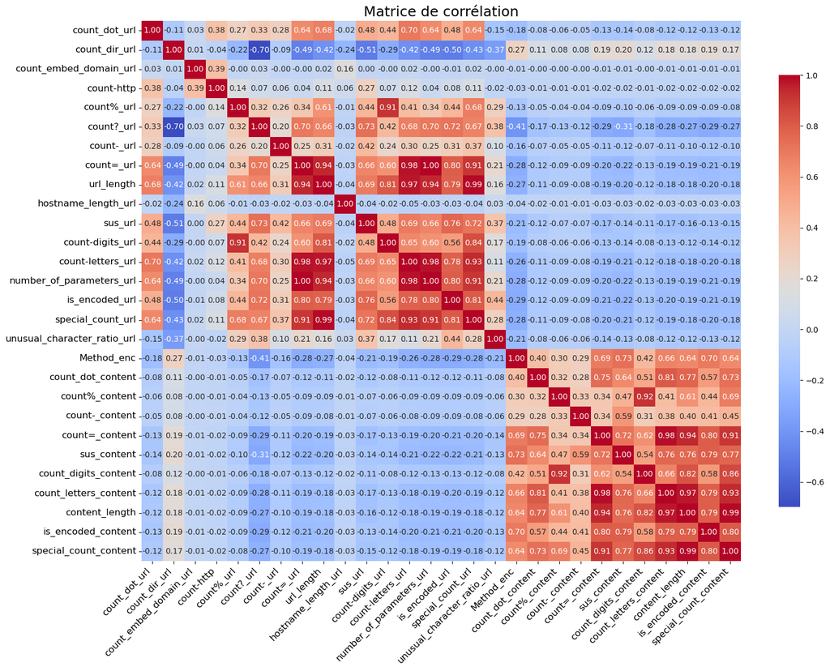

```python
plt.figure(figsize=(16, 12))
sns.heatmap(X[labels].corr(), annot=True, cmap='coolwarm', fmt='.2f', annot_kws={"size": 10}, cbar_kws={"shrink": 0.8})
plt.title("Matrice de corrélation", fontsize=18)
plt.xticks(rotation=45, ha='right', fontsize=12)
plt.yticks(rotation=0, fontsize=12)
plt.tight_layout()
plt.show()
```

La matrice de corrélation nous indique à quel point les variables sont corrélés l'une à l'autre. Globalement on retrouve quatre blocs.

Les variables `count_...` ne sont pas corrélées aux variables `count_..._content`, cependant les variables du type `count_...` sont assez corrélés entre elles, de même pour les variables du type `count_..._content`.

On peut relever certaines corrélations logiques, par exemple entre `count_dot_url` (nombre de points dans une URL) et `count=_url` (nombre d'occurrence "=" dans l'url) avec une valeur de 0.64. On peut l'interpréter comme suit : les URLs avec plus de points tendent aussi à avoir des relations clés-valeurs (séparées par des "="). De même si on reprend nos deux variables cités précédement ainsi que la taille des urls (`url_length`), il y a une corrélation forte entre taille des urls ainsi que la présence de points (0.68) ou encore entre taille des urls et présence de signes "=" (0.94) ce qui signifie la présence de plusieurs paramètres pour une requête (ce qui allonge la taille des urls).

In fine, on retrouve deux groupes de variables assez corrélées entre elles : structure de l'URL et caractéristiques liée au contenu.

The correlation matrix shows how much the variables are correlated with each other. Overall, we can identify four distinct blocks.

The `count_...` variables are not correlated with the `count_..._content` variables. However, variables of the type `count_...` are quite correlated with each other, and the same applies to the `count_..._content` variables.

We can also observe some logical correlations. For example, there’s a correlation of 0.64 between `count_dot_url` (the number of dots in a URL) and `count_=_url` (the number of occurrences of "=" in the URL). This suggests that URLs with more dots tend to also have key-value relationships (separated by "=").

Similarly, if we consider the two variables mentioned above and also the URL length (`url_length`), there is a strong correlation between URL length and the presence of dots (0.68), and even stronger between URL length and the presence of "=" (0.94). This suggests that longer URLs tend to contain multiple parameters (which increases their length).

In the end, we can identify two groups of variables that are fairly correlated with each other: URL structure features and content-related characteristics.

## Visualisaton des proportions des classes - Visualization of class proportions

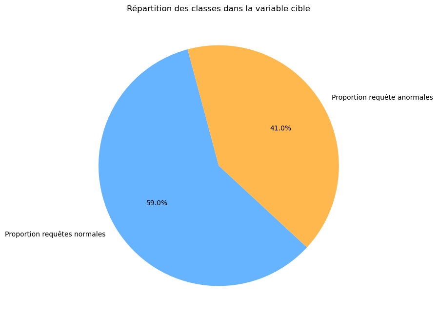

```python
class_counts = y.value_counts()
label = ["Proportion requêtes normales", "Proportion requête anormales"]

plt.figure(figsize=(8, 8))
plt.pie(class_counts, labels=label, autopct='%1.1f%%', startangle=105, colors = ['#66B3FF', '#FFB84D'])
plt.title("Répartition des classes dans la variable cible")
plt.show()
```

# Classifieurs - Classifiers

## Classifieur Bayes Naïf - Naive Bayes Classifier

```python
gnb = GaussianNB()
gnb.fit(X_train, y_train)
y_pred_CNB = gnb.predict(X_test)

print(f"MAE           : {mean_absolute_error(y_test, y_pred_CNB):.3f}")
print(f"Accuracy      : {accuracy_score(y_test, y_pred_CNB):.3f}")
print(f"Precision     : {precision_score(y_test, y_pred_CNB, average='weighted', labels=np.unique(y_pred_CNB)):.3f}")
print(f"Recall        : {recall_score(y_test, y_pred_CNB, average='weighted', labels=np.unique(y_pred_CNB)):.3f}")
print(f"F1            : {f1_score(y_test, y_pred_CNB, average='weighted', labels=np.unique(y_pred_CNB)):.3f}")
print(f"ROC AUC       : {roc_auc_score(y_test, y_pred_CNB, average='weighted', labels=np.unique(y_pred_CNB)):.3f}")
error_nb = (y_pred_CNB != y_test).mean()
print("Taux d'erreur : {:.1%}".format(error_nb))
```

```
MAE           : 0.302
Accuracy      : 0.698
Precision     : 0.705
Recall        : 0.698
F1            : 0.679
ROC AUC       : 0.659
Taux d'erreur : 30.2%
```

### Affichage Bayes Naïf - Plotting Naive Bayes results

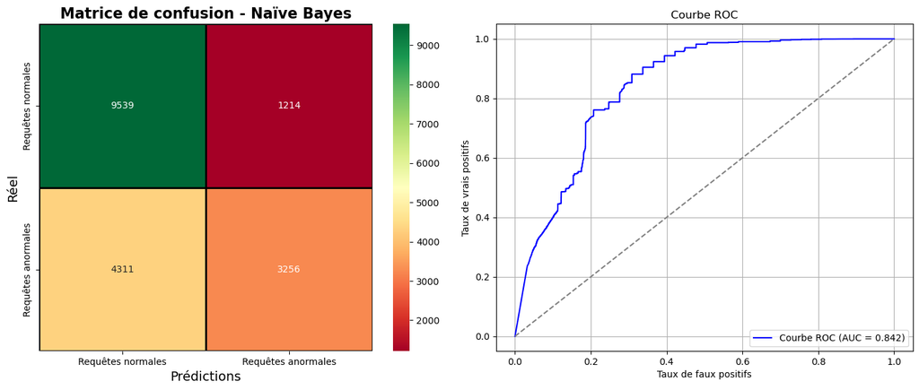

```python
cm = confusion_matrix(y_test, y_pred_CNB)
cm_df = pd.DataFrame(cm, index=['Requêtes normales', 'Requêtes anormales'], columns=['Requêtes normales', 'Requêtes anormales'])

NB_proba = gnb.predict_proba(X_test)
fpr, tpr, thresholds = roc_curve(y_test, NB_proba[:, 1], pos_label=1)
roc_auc = auc(fpr, tpr)

fig, (ax1, ax2) = plt.subplots(1, 2, figsize=(14, 6))

sns.heatmap(cm_df, cmap="RdYlGn", linecolor='black', linewidth=1, annot=True, fmt='d', xticklabels=['Requêtes normales', 'Requêtes anormales'], yticklabels=['Requêtes normales', 'Requêtes anormales'], ax=ax1)
ax1.set_title("Matrice de confusion - Naïve Bayes", fontsize=16, fontweight='bold')
ax1.set_xlabel("Prédictions", fontsize=14)
ax1.set_ylabel("Réel", fontsize=14)

ax2.plot(fpr, tpr, color='blue', label=f'Courbe ROC (AUC = {roc_auc:.3f})')
ax2.plot([0, 1], [0, 1], color='gray', linestyle='--')
ax2.set_xlabel('Taux de faux positifs')
ax2.set_ylabel('Taux de vrais positifs')
ax2.set_title('Courbe ROC')
ax2.legend(loc='lower right')
ax2.grid(True)

plt.tight_layout()
plt.show()
```

Ici nous avons une matrice de confusion représentant les vrais positifs (en haut à gauche), faux positifs (en haut à droite), faux négatifs (en bas à gauche) et les vrais positifs (en bas à droite).

Les vrais positifs et les vrais négatifs indiquent que les prédictions sont exactes, les faux positifs indiquent que le modèle a mal prédit la classe positive, enfin les faux négatifs indiquent que le modèle n'a pas réussi à identifier et à prédire la classe positive.

Dans notre modèle, selon le classifieur naïf de Bayes, comme nous l'avons vu plus haut, environ 30% des requêtes sont mal prédites.

La courbe ROC *(Receiver Operating Characteristic)* elle représente le compromis entre le taux de vrais positifs et le taux de faux positifs. En abscisse, on représente le taux de faux positifs, cet axe représente la proportion de négatifs réels qui sont incorrectement classés comme positifs. En ordonnée est représenté le taux de vrais positifs, cet axe représente la proportion de positifs réels qui sont correctement classés comme positifs. De plus on retrouve un coefficient en légende, le coefficient AUC *(Area Under the Curve)* qui mesure l'aire sous la courbe ROC, plus la valeur est proche de 1, plus le modèle tend vers une valeur parfaite, une valeur inférieur à 0.5 est un modèle pire que le hasard. Ici AUC vaut 0.842 ce qui est une assez bonne valeur de discrimination.

Here we have a confusion matrix representing true positives (top left), false positives (top right), false negatives (bottom left), and true negatives (bottom right).

True positives and true negatives indicate that the predictions are correct, false positives indicate that the model has misclassified a negative instance as positive, and false negatives indicate that the model failed to identify and predict the positive class.

In our model, according to the Naive Bayes classifier, as mentioned earlier, approximately 30% of the requests are misclassified.

The ROC curve (Receiver Operating Characteristic) represents the trade-off between the true positive rate and the false positive rate. On the x-axis, we represent the false positive rate, which is the proportion of actual negatives incorrectly classified as positives. On the y-axis, we represent the true positive rate, which is the proportion of actual positives correctly classified as positives. Additionally, there is a coefficient in the legend, the AUC coefficient (Area Under the Curve), which measures the area under the ROC curve. The closer the value is to 1, the better the model’s performance, with a value lower than 0.5 indicating a model worse than random guessing. Here, the AUC is 0.842, which is a fairly good discrimination value.

## Classifieur des plus proches voisins - KNN Classifier

```python
KNN = KNeighborsClassifier()
neighbors = {'n_neighbors': [1, 3, 4, 5, 6, 7, 9, 11, 13]}

grid_search = GridSearchCV(KNN, neighbors, cv=5)
grid_search.fit(X_train, y_train)

best_neighbors = grid_search.best_params_['n_neighbors']
print("Meilleur voisin : ", best_neighbors)

calibrated_model = KNeighborsClassifier(n_neighbors=best_neighbors)
calibrated_model.fit(X_train, y_train)

KNN_predictions = calibrated_model.predict(X_test)
```

```
Meilleur voisin :  5
```

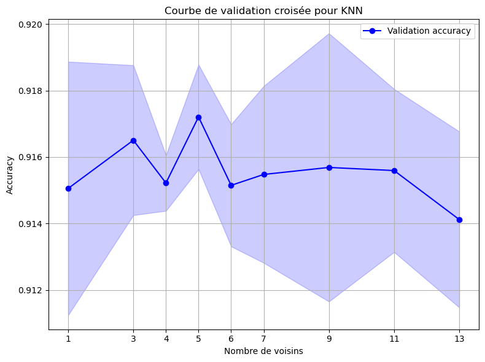

```python
plt.figure(figsize=(8, 6))
results = grid_search.cv_results_
plt.plot(results['param_n_neighbors'], results['mean_test_score'], marker='o', color='b', label='Validation accuracy')
plt.fill_between(results['param_n_neighbors'], results['mean_test_score'] - results['std_test_score'], results['mean_test_score'] + results['std_test_score'], color='blue', alpha=0.2)
plt.title('Courbe de validation croisée pour KNN')
plt.xlabel('Nombre de voisins')
plt.ylabel('Accuracy')
plt.xticks(results['param_n_neighbors'])
plt.grid(True)
plt.legend()
plt.tight_layout()
plt.show()
```

Ici nous avons tracé une courbe de validation croisée pour KNN afin de déterminer le nombre de voisin le plus adapté à notre dataset. Nous avions commencer par essayer des nombres de voisins paires avant de nous rendre compte que la performance se détériorait avec un nombre de voisins croissant. En tatônnant et en testant plusieurs valeurs, les meilleurs résultats se situaient entre 2 et 9 voisins. La validation croisée nous a permis de déterminer le bon paramètre, à savoir, K = 5. Ceci est observable sur la figure ci-dessus.

Here, we have plotted a cross-validation curve for KNN to determine the most suitable number of neighbors for our dataset. We initially started by testing even numbers of neighbors before realizing that performance deteriorated as the number of neighbors increased. Through trial and error and testing several values, the best results were found between 2 and 9 neighbors. The cross-validation allowed us to determine the optimal parameter, which is K = 5. This is observable in the figure above.

```python
print(f"MAE           : {mean_absolute_error(y_test, KNN_predictions):.3f}")
print(f"Accuracy      : {accuracy_score(y_test, KNN_predictions):.3f}")
print(f"Precision     : {precision_score(y_test, KNN_predictions, average='weighted', labels=np.unique(KNN_predictions)):.3f}")
print(f"Recall        : {recall_score(y_test, KNN_predictions, average='weighted', labels=np.unique(KNN_predictions)):.3f}")
print(f"F1            : {f1_score(y_test, KNN_predictions, average='weighted', labels=np.unique(KNN_predictions)):.3f}")
print(f"ROC AUC       : {roc_auc_score(y_test, KNN_predictions, average='weighted', labels=np.unique(KNN_predictions)):.3f}")
error_knn = (KNN_predictions != y_test).mean()
print("Taux d'erreur : {:.1%}".format(error_knn))
```

```
MAE           : 0.084
Accuracy      : 0.916
Precision     : 0.916
Recall        : 0.916
F1            : 0.916
ROC AUC       : 0.913
Taux d'erreur : 8.4%
```

### Affichage KNN - Plotting KNN results

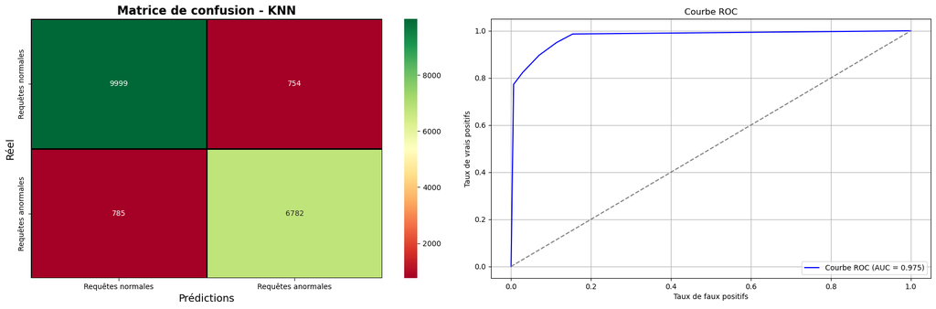

```python
fig, axes = plt.subplots(1, 2, figsize=(18, 6))

# Matrice de confusion
cm_knn = confusion_matrix(y_test, KNN_predictions)
cm_knn_df = pd.DataFrame(cm_knn, index=['Requêtes normales', 'Requêtes anormales'], columns=['Requêtes normales', 'Requêtes anormales'])
sns.heatmap(cm_knn_df, cmap="RdYlGn", annot=True, fmt='d', linewidths=1, linecolor='black', xticklabels=['Requêtes normales', 'Requêtes anormales'], yticklabels=['Requêtes normales', 'Requêtes anormales'], ax=axes[0])
axes[0].set_title("Matrice de confusion - KNN", fontsize=16, fontweight='bold')
axes[0].set_xlabel("Prédictions", fontsize=14)
axes[0].set_ylabel("Réel", fontsize=14)

# Courbe ROC
KNN_proba = calibrated_model.predict_proba(X_test)
fpr, tpr, thresholds = roc_curve(y_test, KNN_proba[:, 1], pos_label=1)
roc_auc = auc(fpr, tpr)
axes[1].plot(fpr, tpr, color='blue', label=f'Courbe ROC (AUC = {roc_auc:.3f})')
axes[1].plot([0, 1], [0, 1], color='gray', linestyle='--')
axes[1].set_xlabel('Taux de faux positifs')
axes[1].set_ylabel('Taux de vrais positifs')
axes[1].set_title('Courbe ROC')
axes[1].legend(loc='lower right')
axes[1].grid(True)

plt.tight_layout()
plt.show()
```

D'après la matrice de confusion, les scores de prédictions sont très satisfaisant, peu d'éléments sont prédits dans une classe à laquelle ils n'appartient pas. Par rapport à la courbe ROC, on note :

- La courbe monte rapidement vers le point (0, 1), ce qui indique que le modèle atteint un haut taux de vrais positifs avec un faible taux de faux positifs.
- La courbe se stabilise ensuite près du point (1, 1), ce qui montre que le modèle continue à bien performer même lorsque le seuil de décision est abaissé.
- De plus la valeur AUC est très proche de 1, ce qui soulève une excellente performance globale du modèle.

La courbe de validation croisée et les calculs effectués plus haut nous permettent de conclure sur la bonne performance du classifieur KNN pour notre modèle.

Based on the confusion matrix, the prediction scores are very satisfactory, with few elements being misclassified into a class they don't belong to.

Regarding the ROC curve, we observe the following:

- The curve rises quickly towards the point (0, 1), indicating that the model achieves a high true positive rate with a low false positive rate.
- The curve then stabilizes near the point (1, 1), showing that the model continues to perform well even as the decision threshold is lowered.
- Additionally, the AUC value is very close to 1, which indicates excellent overall performance of the model.

The cross-validation curve and the calculations performed earlier allow us to conclude that the KNN classifier performs well for our model.

## Classifieur LDA - Linear Discriminant Analysis

```python
lda = LinearDiscriminantAnalysis()
lda.fit(X_train, y_train)

y_pred_LDA = lda.predict(X_test)
print(f"MAE           : {mean_absolute_error(y_test, y_pred_LDA):.3f}")
print(f"Accuracy      : {accuracy_score(y_test, y_pred_LDA):.3f}")
print(f"Precision     : {precision_score(y_test, y_pred_LDA, average='weighted', labels=np.unique(y_pred_LDA)):.3f}")
print(f"Recall        : {recall_score(y_test, y_pred_LDA, average='weighted', labels=np.unique(y_pred_LDA)):.3f}")
print(f"F1            : {f1_score(y_test, y_pred_LDA, average='weighted', labels=np.unique(y_pred_LDA)):.3f}")
print(f"ROC AUC       : {roc_auc_score(y_test, y_pred_LDA, average='weighted', labels=np.unique(y_pred_LDA)):.3f}")
error_lda = (y_pred_LDA != y_test).mean()
print("Taux d'erreur : {:.1%}".format(error_lda))
```

```
MAE           : 0.242
Accuracy      : 0.758
Precision     : 0.757
Recall        : 0.758
F1            : 0.754
ROC AUC       : 0.739
Taux d'erreur : 24.2%
```

### Affichage LDA - Plotting LDA results

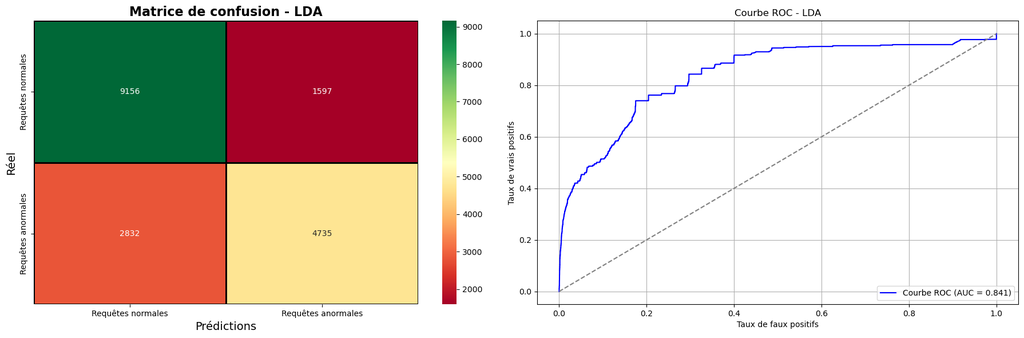

```python
y_pred_LDA = lda.predict(X_test)
y_proba_LDA = lda.predict_proba(X_test)
fpr_lda, tpr_lda, thresholds_lda = roc_curve(y_test, y_proba_LDA[:, 1], pos_label=1)
roc_auc_lda = auc(fpr_lda, tpr_lda)
cm_lda = confusion_matrix(y_test, y_pred_LDA)
cm_lda_df = pd.DataFrame(cm_lda, index=['Requêtes normales', 'Requêtes anormales'], columns=['Requêtes normales', 'Requêtes anormales'])

fig, axes = plt.subplots(1, 2, figsize=(18, 6))

sns.heatmap(cm_lda_df, cmap="RdYlGn", annot=True, fmt='d', linewidths=1, linecolor='black', xticklabels=['Requêtes normales', 'Requêtes anormales'], yticklabels=['Requêtes normales', 'Requêtes anormales'], ax=axes[0])
axes[0].set_title("Matrice de confusion - LDA", fontsize=16, fontweight='bold')
axes[0].set_xlabel("Prédictions", fontsize=14)
axes[0].set_ylabel("Réel", fontsize=14)

axes[1].plot(fpr_lda, tpr_lda, color='blue', label=f'Courbe ROC (AUC = {roc_auc_lda:.3f})')
axes[1].plot([0, 1], [0, 1], color='gray', linestyle='--')
axes[1].set_xlabel('Taux de faux positifs')
axes[1].set_ylabel('Taux de vrais positifs')
axes[1].set_title('Courbe ROC - LDA')
axes[1].legend(loc='lower right')
axes[1].grid(True)

plt.tight_layout()
plt.show()
```

Ici, nous avons de meilleures performances globale par rapport à naïf Bayes, mais les classifieurs sont assez similaires.

## Classifieur QDA - Quadratic Discriminant Analysis

```python
qda = QuadraticDiscriminantAnalysis()
qda.fit(X_train, y_train)

y_pred_QDA = qda.predict(X_test)
print(f"MAE           : {mean_absolute_error(y_test, y_pred_QDA):.3f}")
print(f"Accuracy      : {accuracy_score(y_test, y_pred_QDA):.3f}")
print(f"Precision     : {precision_score(y_test, y_pred_QDA, average='weighted', labels=np.unique(y_pred_QDA)):.3f}")
print(f"Recall        : {recall_score(y_test, y_pred_QDA, average='weighted', labels=np.unique(y_pred_QDA)):.3f}")
print(f"F1            : {f1_score(y_test, y_pred_QDA, average='weighted', labels=np.unique(y_pred_QDA)):.3f}")
print(f"ROC AUC       : {roc_auc_score(y_test, y_pred_QDA, average='weighted', labels=np.unique(y_pred_QDA)):.3f}")
error_qda = (y_pred_QDA != y_test).mean()
print("Taux d'erreur : {:.1%}".format(error_qda))
```

```
MAE           : 0.305
Accuracy      : 0.695
Precision     : 0.792
Recall        : 0.695
F1            : 0.639
ROC AUC       : 0.632
Taux d'erreur : 30.5%
```

### Affichage QDA - Plotting QDA results

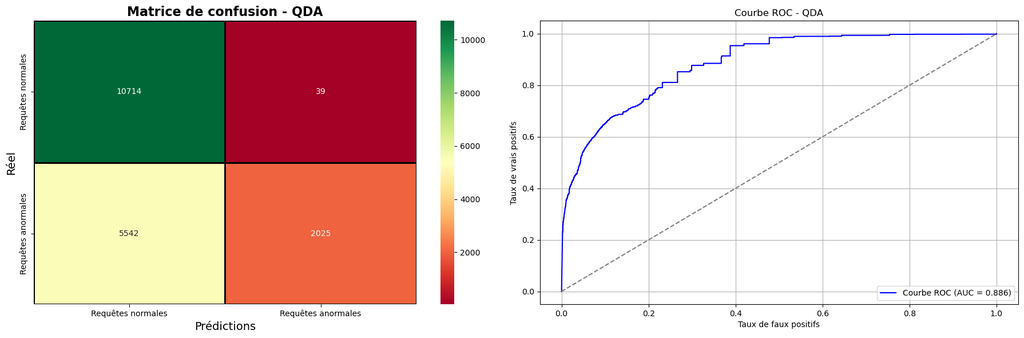

```python
y_pred_QDA = qda.predict(X_test)
y_proba_QDA = qda.predict_proba(X_test)
fpr_qda, tpr_qda, thresholds_qda = roc_curve(y_test, y_proba_QDA[:, 1], pos_label=1)
roc_auc_qda = auc(fpr_qda, tpr_qda)
cm_qda = confusion_matrix(y_test, y_pred_QDA)
cm_qda_df = pd.DataFrame(cm_qda, index=['Requêtes normales', 'Requêtes anormales'], columns=['Requêtes normales', 'Requêtes anormales'])

fig, axes = plt.subplots(1, 2, figsize=(18, 6))

sns.heatmap(cm_qda_df, cmap="RdYlGn", annot=True, fmt='d', linewidths=1, linecolor='black', xticklabels=['Requêtes normales', 'Requêtes anormales'], yticklabels=['Requêtes normales', 'Requêtes anormales'], ax=axes[0])
axes[0].set_title("Matrice de confusion - QDA", fontsize=16, fontweight='bold')
axes[0].set_xlabel("Prédictions", fontsize=14)
axes[0].set_ylabel("Réel", fontsize=14)

axes[1].plot(fpr_qda, tpr_qda, color='blue', label=f'Courbe ROC (AUC = {roc_auc_qda:.3f})')
axes[1].plot([0, 1], [0, 1], color='gray', linestyle='--')
axes[1].set_xlabel('Taux de faux positifs')
axes[1].set_ylabel('Taux de vrais positifs')
axes[1].set_title('Courbe ROC - QDA')
axes[1].legend(loc='lower right')
axes[1].grid(True)

plt.tight_layout()
plt.show()
```

Ici, les performances encore une fois sont assez similaires avec NB et LDA, ce qui n'est pas très étonnant d'un point de vue théorique. Cependant on peut remarquer le nombre de faux postifs très faible et un taux assez élevé de faux négatifs.

## Arbre de décision - Decision Tree

```python
DT = tree.DecisionTreeClassifier()
DT = DT.fit(X_train, y_train)

y_pred_DT = DT.predict(X_test)
print(f"MAE           : {mean_absolute_error(y_test, y_pred_DT):.3f}")
print(f"Accuracy      : {accuracy_score(y_test, y_pred_DT):.3f}")
print(f"Precision     : {precision_score(y_test, y_pred_DT, average='weighted', labels=np.unique(y_pred_DT)):.3f}")
print(f"Recall        : {recall_score(y_test, y_pred_DT, average='weighted', labels=np.unique(y_pred_DT)):.3f}")
print(f"F1            : {f1_score(y_test, y_pred_DT, average='weighted', labels=np.unique(y_pred_DT)):.3f}")
print(f"ROC AUC       : {roc_auc_score(y_test, y_pred_DT, average='weighted', labels=np.unique(y_pred_DT)):.3f}")
error_DT = (y_pred_DT != y_test).mean()
print("Taux d'erreur : {:.1%}".format(error_DT))
```

```
MAE           : 0.084
Accuracy      : 0.916
Precision     : 0.916
Recall        : 0.916
F1            : 0.916
ROC AUC       : 0.912
Taux d'erreur : 8.4%
```

### Création de l'arbre de décision complet - Creation of the complete decision tree

```python
nb_leaves = DT.get_n_leaves()
print('Nb feuilles DT =', nb_leaves)

dot_data = tree.export_graphviz(DT, out_file=None)
graph = graphviz.Source(dot_data)
graph.render("Requêtes")

dot_data = tree.export_graphviz(DT, out_file=None, feature_names=labels, class_names=['Anormales','Normales'], filled=True, rounded=True, special_characters=True)
graph = graphviz.Source(dot_data)
graph.render("Requêtes_DT_Complet")
```

```
Nb feuilles DT = 2690
```

```
'Requêtes_DT_Complet.pdf'
```

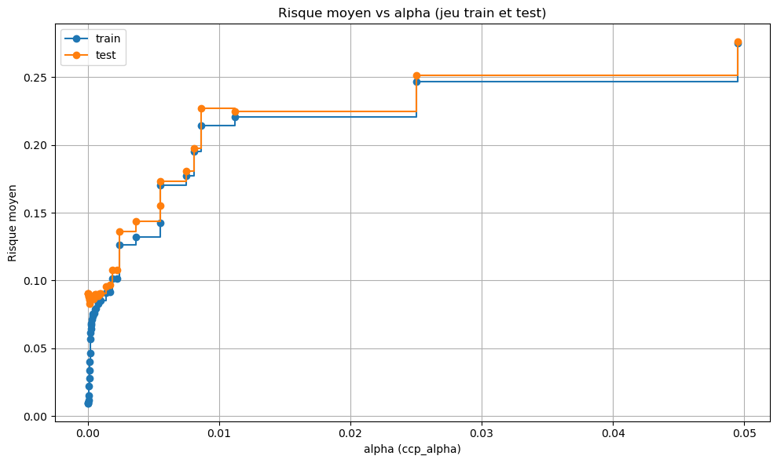

```python
# Sous-échantillonnage (10 000 observations pour gain de temps)
X_train_sub = X_train.sample(10000, random_state=0)
y_train_sub = y_train.loc[X_train_sub.index]

X_test_sub = X_test.sample(10000, random_state=0)
y_test_sub = y_test.loc[X_test_sub.index]

DT2 = DecisionTreeClassifier(random_state=0)
path = DT2.cost_complexity_pruning_path(X_train_sub, y_train_sub)
ccp_alphas, impurities = path.ccp_alphas, path.impurities

# Nettoyage des alphas
ccp_alphas = ccp_alphas[ccp_alphas > 0]               # Supprime le 0 (non élagué)
ccp_alphas = np.unique(np.round(ccp_alphas, 5))       # Arrondi pour réduire le nombre d’arbres quasi identiques
ccp_alphas = ccp_alphas[::2]                          # Prend 1 alpha sur 2 pour encore plus de vitesse

# Stockage des modèles et risques
stocks_DT2 = []
stock_risk_train = []
stock_risk_test = []

for ccp_alpha in ccp_alphas:
    DT2_alpha = DecisionTreeClassifier(random_state=0, ccp_alpha=ccp_alpha)
    DT2_alpha.fit(X_train_sub, y_train_sub)
    stocks_DT2.append(DT2_alpha)

    YhatTrain = DT2_alpha.predict(X_train_sub)
    YhatTest = DT2_alpha.predict(X_test_sub)

    stock_risk_train.append(1 - np.mean(y_train_sub == YhatTrain))
    stock_risk_test.append(1 - np.mean(y_test_sub == YhatTest))

fig, ax = plt.subplots(figsize=(10, 6))
ax.set_xlabel("alpha (ccp_alpha)")
ax.set_ylabel("Risque moyen")
ax.set_title("Risque moyen vs alpha (jeu train et test)")
ax.plot(ccp_alphas, stock_risk_train, marker="o", label="train", drawstyle="steps-post")
ax.plot(ccp_alphas, stock_risk_test, marker="o", label="test", drawstyle="steps-post")
ax.legend()
plt.grid(True)
plt.tight_layout()
plt.show()
```

### Élagage de l'abre de décision - Decision Tree Pruning

```python
DT_elague = DecisionTreeClassifier(random_state=0, ccp_alpha=0.005)
DT_elague.fit(X_train, y_train)

nb_leaves = DT_elague.get_n_leaves()
print('Nb feuilles DT_elague =', nb_leaves)

# Risk Train DT :
YhatTrain = DT_elague.predict(X_train)
Risk_DT_TRain = 1-np.sum(y_train==YhatTrain)/len(y_train)
print(f"Risk Train DT_elague = {Risk_DT_TRain:.3f}")

# Risk Test DT :
YhatTest = DT_elague.predict(X_test)
Risk_DT_Test = 1-np.sum(y_test==YhatTest)/len(y_test)
print(f"Risk Test DT_elague = {Risk_DT_Test:.3f}")
```

```
Nb feuilles DT_elague = 22
Risk Train DT_elague = 0.145
Risk Test DT_elague = 0.150
```

### Affichage arbre de décision élagué - Plotting pruned Decision Tree

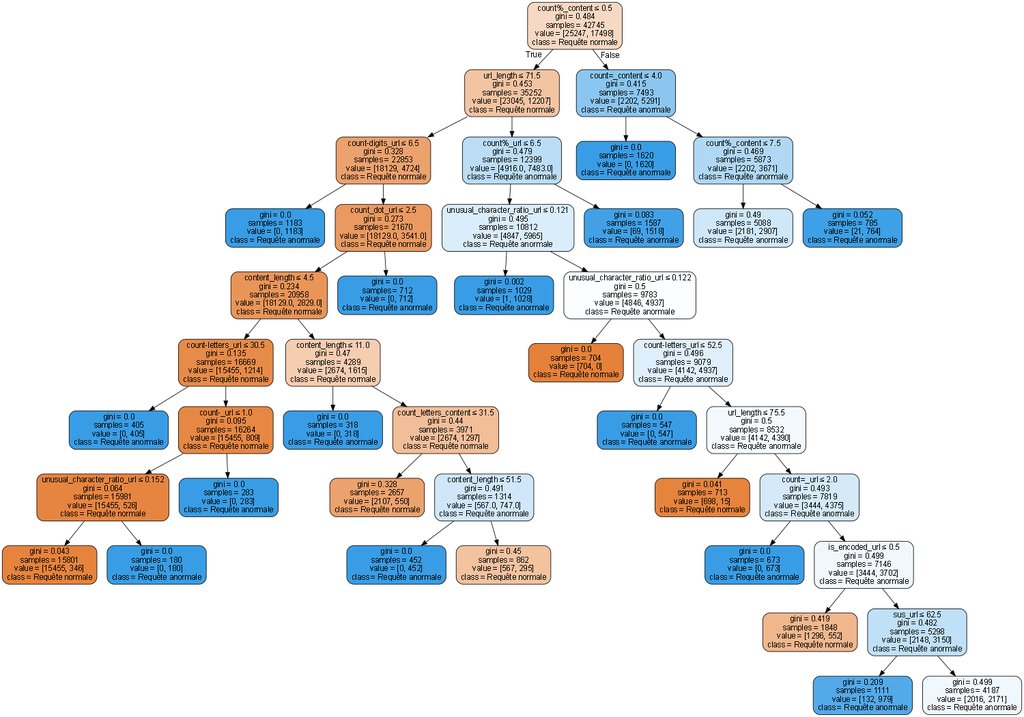

```python
dot_data = tree.export_graphviz(
    DT_elague,
    out_file=None,
    feature_names=labels,
    class_names=['Requête normale', 'Requête anormale'],
    filled=True,
    rounded=True,
    special_characters=True
)

dot_data = 'digraph Tree {\n' + 'graph [size="10,10!", dpi=150];\n' + dot_data.split('\n', 1)[1]

graph = graphviz.Source(dot_data)
output_path = "Requêtes_DT_élagué"
graph.render(output_path, format="png", cleanup=True)

display(Image(filename=output_path + ".png"))
```

## Régression logistique - Logistic Regression

```python
d = X_train.shape[1]
nTrain = X_train.shape[0]
print('nTrain =', nTrain)
nTest = X_test.shape[0]
print('nTest =', nTest)
```

```
nTrain = 42745
nTest = 18320
```

```python
warnings.filterwarnings("ignore")

LR_model = LogisticRegression(max_iter = 10000)
LR_model.fit(X_train, y_train)
y_pred_LR = LR_model.predict(X_test)

print(f"MAE           : {mean_absolute_error(y_test, y_pred_LR):.3f}")
print(f"Accuracy      : {accuracy_score(y_test, y_pred_LR):.3f}")
print(f"Precision     : {precision_score(y_test, y_pred_LR, average='weighted', labels=np.unique(y_pred_LR)):.3f}")
print(f"Recall        : {recall_score(y_test, y_pred_LR, average='weighted', labels=np.unique(y_pred_LR)):.3f}")
print(f"F1            : {f1_score(y_test, y_pred_LR, average='weighted', labels=np.unique(y_pred_LR)):.3f}")
print(f"ROC AUC       : {roc_auc_score(y_test, LR_model.predict_proba(X_test)[:, 1]):.3f}")
error_LR = (y_pred_LR != y_test).mean()
print(f"Taux d'erreur : {error_LR:.1%}")
```

```
MAE           : 0.217
Accuracy      : 0.783
Precision     : 0.784
Recall        : 0.783
F1            : 0.779
ROC AUC       : 0.849
Taux d'erreur : 21.7%
```

### Affichage régression logistique - Plotting Logistic Regression results

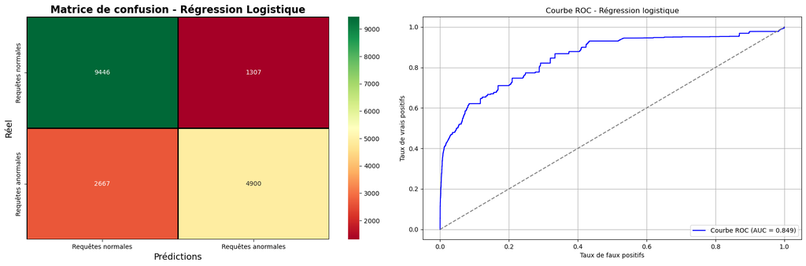

```python
y_pred_LR = LR_model.predict(X_test)
y_proba_LR = LR_model.predict_proba(X_test)
fpr_lr, tpr_lr, thresholds_lr = roc_curve(y_test, y_proba_LR[:, 1], pos_label=1)
roc_auc_lr = auc(fpr_lr, tpr_lr)
cm_lr = confusion_matrix(y_test, y_pred_LR)
cm_lr_df = pd.DataFrame(cm_lr, index=['Requêtes normales', 'Requêtes anormales'], columns=['Requêtes normales', 'Requêtes anormales'])

fig, axes = plt.subplots(1, 2, figsize=(18, 6))

sns.heatmap(cm_lr_df, cmap="RdYlGn", annot=True, fmt='d', linewidths=1, linecolor='black', xticklabels=['Requêtes normales', 'Requêtes anormales'], yticklabels=['Requêtes normales', 'Requêtes anormales'], ax=axes[0])
axes[0].set_title("Matrice de confusion - Régression Logistique", fontsize=16, fontweight='bold')
axes[0].set_xlabel("Prédictions", fontsize=14)
axes[0].set_ylabel("Réel", fontsize=14)

axes[1].plot(fpr_lr, tpr_lr, color='blue', label=f'Courbe ROC (AUC = {roc_auc_lr:.3f})')
axes[1].plot([0, 1], [0, 1], color='gray', linestyle='--')
axes[1].set_xlabel('Taux de faux positifs')
axes[1].set_ylabel('Taux de vrais positifs')
axes[1].set_title('Courbe ROC - Régression logistique')
axes[1].legend(loc='lower right')
axes[1].grid(True)

plt.tight_layout()
plt.show()
```

## Validation croisée - Cross-Validation

```python
warnings.filterwarnings("ignore")

label_encoder = LabelEncoder()
y = label_encoder.fit_transform(y)  # Convertir 'Normal' et 'Anormal' en 0 et 1
X = X[labels].apply(pd.to_numeric, errors='coerce')
X_train, X_test, y_train, y_test = train_test_split(X, y, test_size=0.3, random_state=0)

nbFolds = 10
kf = KFold(n_splits=nbFolds, shuffle=True)

stock_risk_LR_Train = np.zeros(nbFolds)
stock_risk_LR_Val = np.zeros(nbFolds)
stock_risk_NB_Train = np.zeros(nbFolds)
stock_risk_NB_Val = np.zeros(nbFolds)
stock_risk_LDA_Train = np.zeros(nbFolds)
stock_risk_LDA_Val = np.zeros(nbFolds)
stock_risk_QDA_Train = np.zeros(nbFolds)
stock_risk_QDA_Val = np.zeros(nbFolds)
stock_risk_RF_Train = np.zeros(nbFolds)
stock_risk_RF_Val = np.zeros(nbFolds)
stock_risk_KNN_Train = np.zeros(nbFolds)
stock_risk_KNN_Val = np.zeros(nbFolds)

errors_LR = []
errors_LDA = []
errors_NB = []
errors_QDA = []
errors_RF = []
errors_KNN = []

f = 0

for train, val in kf.split(X, y):
    print("Processing fold f =", f)
    print("\n")

    X_train_fold, X_val_fold = X.iloc[train], X.iloc[val]
    y_train_fold, y_val_fold = y[train], y[val]

    # Régression Logistique
    LR_model = LogisticRegression(max_iter=10000)
    LR_model.fit(X_train_fold, y_train_fold)
    Yhat_Train_LR = LR_model.predict(X_train_fold)
    stock_risk_LR_Train[f] = np.mean(Yhat_Train_LR != y_train_fold)
    Yhat_val_LR = LR_model.predict(X_val_fold)
    stock_risk_LR_Val[f] = np.mean(Yhat_val_LR != y_val_fold)

    # Classifieur Naïf de Bayes
    CNB = GaussianNB()
    CNB.fit(X_train_fold, y_train_fold)
    Yhat_Train_NB = CNB.predict(X_train_fold)
    stock_risk_NB_Train[f] = np.mean(Yhat_Train_NB != y_train_fold)
    Yhat_val_NB = CNB.predict(X_val_fold)
    stock_risk_NB_Val[f] = np.mean(Yhat_val_NB != y_val_fold)

    # QDA
    qda = QuadraticDiscriminantAnalysis()
    qda.fit(X_train_fold, y_train_fold)
    Yhat_Train_QDA = qda.predict(X_train_fold)
    stock_risk_QDA_Train[f] = np.mean(Yhat_Train_QDA != y_train_fold)
    Yhat_val_QDA = qda.predict(X_val_fold)
    stock_risk_QDA_Val[f] = np.mean(Yhat_val_QDA != y_val_fold)

    # LDA
    lda = LinearDiscriminantAnalysis()
    lda.fit(X_train_fold, y_train_fold)
    Yhat_Train_LDA = lda.predict(X_train_fold)
    stock_risk_LDA_Train[f] = np.mean(Yhat_Train_LDA != y_train_fold)
    Yhat_val_LDA = lda.predict(X_val_fold)
    stock_risk_LDA_Val[f] = np.mean(Yhat_val_LDA != y_val_fold)

    # Random Forest
    RF_model = RandomForestClassifier(random_state=0, ccp_alpha=0.005)
    RF_model.fit(X_train_fold, y_train_fold)
    Yhat_Train_RF = RF_model.predict(X_train_fold)
    stock_risk_RF_Train[f] = np.mean(Yhat_Train_RF != y_train_fold)
    Yhat_val_RF = RF_model.predict(X_val_fold)
    stock_risk_RF_Val[f] = np.mean(Yhat_val_RF != y_val_fold)

    # KNN
    KNN = KNeighborsClassifier(n_neighbors=5)
    KNN.fit(X_train_fold, y_train_fold)
    Yhat_Train_KNN = KNN.predict(X_train_fold)
    stock_risk_KNN_Train[f] = np.mean(Yhat_Train_KNN != y_train_fold)
    Yhat_val_KNN = KNN.predict(X_val_fold)
    stock_risk_KNN_Val[f] = np.mean(Yhat_val_KNN != y_val_fold)

    errors_LR.append(stock_risk_LR_Val)
    errors_LDA.append(stock_risk_LDA_Val)
    errors_NB.append(stock_risk_NB_Val)
    errors_QDA.append(stock_risk_QDA_Val)
    errors_RF.append(stock_risk_RF_Val)
    errors_KNN.append(stock_risk_KNN_Val)

    f += 1

print("--------------------------------------------------------------")
print("------------- Résultats de la validation croisée -------------")
print("--------------------------------------------------------------")
print("\n")
print(f"Average risk LogisticRegression Train      = {stock_risk_LR_Train.mean():.5f}")
print(f"Average risk LogisticRegression Validation = {stock_risk_LR_Val.mean():.5f}")
print(f"AVG risk NB Train                          = {stock_risk_NB_Train.mean():.5f}")
print(f"AVG risk NB Validation                     = {stock_risk_NB_Val.mean():.5f}")
print(f"AVG risk LDA Train                         = {stock_risk_LDA_Train.mean():.5f}")
print(f"AVG risk LDA Validation                    = {stock_risk_LDA_Val.mean():.5f}")
print(f"AVG risk QDA Train                         = {stock_risk_QDA_Train.mean():.5f}")
print(f"AVG risk QDA Validation                    = {stock_risk_QDA_Val.mean():.5f}")
print(f"AVG risk RandomForest Train                = {stock_risk_RF_Train.mean():.5f}")
print(f"AVG risk RandomForest Validation           = {stock_risk_RF_Val.mean():.5f}")
print(f"AVG risk KNN Train                         = {stock_risk_KNN_Train.mean():.5f}")
print(f"AVG risk KNN Val                           = {stock_risk_KNN_Val.mean():.5f}")
```

```
Processing fold f = 0


Processing fold f = 1


Processing fold f = 2


Processing fold f = 3


Processing fold f = 4


Processing fold f = 5


Processing fold f = 6


Processing fold f = 7


Processing fold f = 8


Processing fold f = 9


--------------------------------------------------------------
------------- Résultats de la validation croisée -------------
--------------------------------------------------------------


Average risk LogisticRegression Train      = 0.21483
Average risk LogisticRegression Validation = 0.21525
AVG risk NB Train                          = 0.30085
AVG risk NB Validation                     = 0.30086
AVG risk LDA Train                         = 0.23865
AVG risk LDA Validation                    = 0.23897
AVG risk QDA Train                         = 0.29669
AVG risk QDA Validation                    = 0.29732
AVG risk RandomForest Train                = 0.14743
AVG risk RandomForest Validation           = 0.14753
AVG risk KNN Train                         = 0.05792
AVG risk KNN Val                           = 0.08330
```

### Affichage validation croisée - Ploting Cross-Validation results

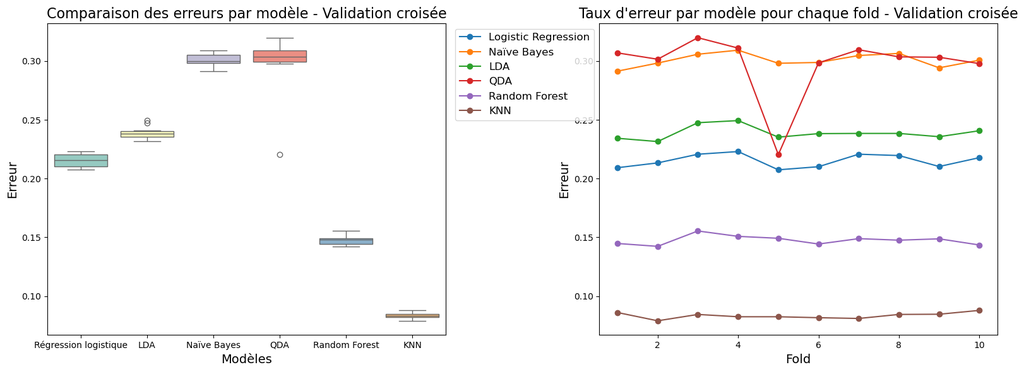

```python
model_names = ['Régression logistique', 'LDA', 'Naïve Bayes', 'QDA', 'Random Forest', 'KNN']
error_arrays = [errors_LR[0], errors_LDA[0], errors_NB[0], errors_QDA[0], errors_RF[0], errors_KNN[0]]
data_boxplot = {model: errors for model, errors in zip(model_names, error_arrays)}
df_errors = pd.DataFrame(data_boxplot)

fig, axes = plt.subplots(1, 2, figsize=(16, 6))

sns.boxplot(data=df_errors, palette='Set3', width=0.8, ax=axes[0])
axes[0].set_title('Comparaison des erreurs par modèle - Validation croisée', fontsize=16)
axes[0].set_ylabel('Erreur', fontsize=14)
axes[0].set_xlabel('Modèles', fontsize=14)

axes[1].plot(range(1, nbFolds + 1), stock_risk_LR_Val, label='Logistic Regression', marker='o')
axes[1].plot(range(1, nbFolds + 1), stock_risk_NB_Val, label='Naïve Bayes', marker='o')
axes[1].plot(range(1, nbFolds + 1), stock_risk_LDA_Val, label='LDA', marker='o')
axes[1].plot(range(1, nbFolds + 1), stock_risk_QDA_Val, label='QDA', marker='o')
axes[1].plot(range(1, nbFolds + 1), stock_risk_RF_Val, label='Random Forest', marker='o')
axes[1].plot(range(1, nbFolds + 1), stock_risk_KNN_Val, label='KNN', marker='o')

axes[1].set_xlabel('Fold', fontsize=14)
axes[1].set_ylabel('Erreur', fontsize=14)
axes[1].set_title('Taux d\'erreur par modèle pour chaque fold - Validation croisée', fontsize=16)
axes[1].legend(loc='upper right', bbox_to_anchor=(0, 1), fontsize=12)

plt.tight_layout()
plt.show()
```

# Affichage des frontières de décision des différents modèles - Displaying decision boundaries of the different models

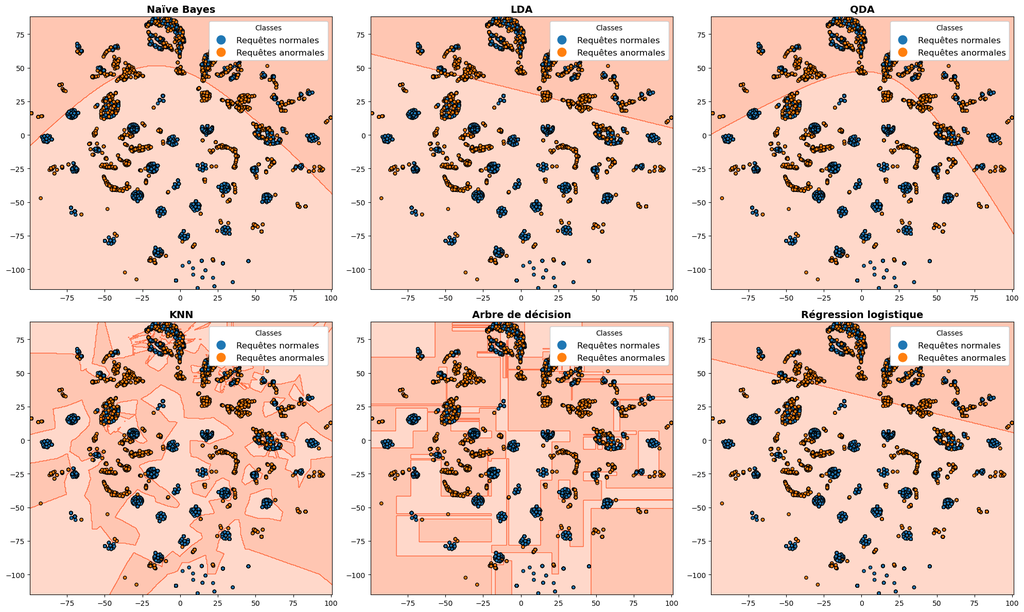

```python
y_train = pd.Series(y_train, index=X_train.index)
y_test  = pd.Series(y_test, index=X_test.index)

X_train = X_train.reset_index(drop=True)
y_train = y_train.reset_index(drop=True)
X_test  = X_test.reset_index(drop=True)
y_test  = y_test.reset_index(drop=True)

X_train_sampled = X_train.sample(6500, random_state=0)
y_train_sampled = y_train.loc[X_train_sampled.index]

X_test_sampled  = X_test.sample(6500, random_state=0)
y_test_sampled  = y_test.loc[X_test_sampled.index]

# t-SNE sur les données train et test
tsne = TSNE(n_components=2, random_state=0)
X_train_tsne = tsne.fit_transform(X_train_sampled)
X_test_tsne  = tsne.fit_transform(X_test_sampled)

# Initialisation des classificateurs
gnb = GaussianNB()
lda = LinearDiscriminantAnalysis()
qda = QuadraticDiscriminantAnalysis()
knn = KNeighborsClassifier(n_neighbors=5)
dt  = tree.DecisionTreeClassifier(random_state=0)
lr  = LogisticRegression(random_state=0)

classifiers = [gnb, lda, qda, knn, dt, lr]
titles = ['Naïve Bayes', 'LDA', 'QDA', 'KNN', 'Arbre de décision', 'Régression logistique']

for clf in classifiers:
    clf.fit(X_train_tsne, y_train_sampled)

x_min, x_max = X_train_tsne[:, 0].min() - 1, X_train_tsne[:, 0].max() + 1
y_min, y_max = X_train_tsne[:, 1].min() - 1, X_train_tsne[:, 1].max() + 1

xx, yy = np.meshgrid(np.arange(x_min, x_max, 0.5),
                     np.arange(y_min, y_max, 0.5))
grid_points = np.c_[xx.ravel(), yy.ravel()]

def predict_batch(clf, grid, batch_size=10000):
    preds = []
    for i in range(0, grid.shape[0], batch_size):
        batch = grid[i:i+batch_size]
        preds.append(clf.predict(batch))
    return np.concatenate(preds)

cmap_light = ListedColormap(['#FF7F50', '#FF6347', '#FF4500'])
cmap_bold  = ListedColormap(['#1F77B4', '#17BECF', '#FF7F0E'])

fig, axes = plt.subplots(2, 3, figsize=(20, 12))

for i, clf in enumerate(classifiers):
    Z = predict_batch(clf, grid_points)
    Z = Z.reshape(xx.shape)

    ax = axes[i // 3, i % 3]
    ax.contourf(xx, yy, Z, alpha=0.3, cmap=cmap_light)
    scatter = ax.scatter(X_train_tsne[:, 0], X_train_tsne[:, 1],
                         c=y_train_sampled, cmap=cmap_bold, edgecolor='k', s=20)

    ax.set_xlim(xx.min(), xx.max())
    ax.set_ylim(yy.min(), yy.max())
    ax.set_title(titles[i], fontsize=14, fontweight='bold')

    handles, labels = scatter.legend_elements()
    leg = ax.legend(handles, ['Requêtes normales', 'Requêtes anormales'],
                    title="Classes", loc='upper right',
                    fontsize=12, title_fontsize=10, markerscale=2, framealpha=1)

plt.tight_layout()
plt.show()
```

# Critiques et améliorations possibles - Feedback and Possible Improvements

Au cours du semestre, nous avons eu l'occasion d'appliquer les classifieurs étudiés en cours. Pour la base de données choisie, d'après notre étude, le classifieur des plus proches voisins (KNN) s'avère être le meilleur modèle. Le taux d'erreur y est faible (~8%). La validation croisée confirme nos observations sur KNN, qui présente les risques d'erreur les plus faibles parmi tous les classifieurs.

Le tracé des frontières de décision révèle des éléments intéressants sur nos données. Sans se concentrer sur un modèle en particulier, on peut observer la présence de plusieurs clusters. Nous avons vu en cours que la classification non supervisée est un outil puissant pour explorer et analyser des données complexes.

Ainsi, une piste d'amélioration serait de tester des méthodes de classification non supervisée, notamment la méthode de Spectral Clustering ou encore l'algorithme EM pour Mixture Gaussiennes, qui semblent particulièrement adaptées à la structure de nos données.

De plus, bien que la base utilisée ait fait l'objet d'un prétraitement, avec un encodage de certaines variables afin de pouvoir travailler avec des données numériques, nous n'avons pas détaillé dans ce notebook les principes sous-jacents de cette étape. Il aurait également été pertinent de mener une analyse statistique plus approfondie de nos données.

Enfin, ce projet nous a permis de nous familiariser avec les pratiques courantes en machine learning, notamment grâce à l'utilisation de scikit-learn, et ces principes pourront être réutilisés dans des projets futurs.

Throughout the semester, we had the opportunity to apply the classifiers studied in class. For the chosen dataset, based on our analysis, the k-Nearest Neighbors (KNN) classifier proved to be the best model. The error rate is low (~8%). Cross-validation further confirms our findings, showing that KNN has the lowest error risks among all classifiers.

The plotting of decision boundaries reveals interesting insights into our data. Without focusing on any particular model, we can observe the presence of several clusters. As we discussed in class, unsupervised classification is a powerful tool for exploring and analyzing complex data.

One area for improvement would be to test unsupervised classification methods, particularly Spectral Clustering or the EM algorithm for Gaussian Mixture Models, which seem particularly well-suited to the structure of our data.

Additionally, although the dataset underwent preprocessing, including the encoding of certain variables to allow for numerical data handling, we did not detail the underlying principles of this step in this notebook. A more in-depth statistical analysis of the data would have also been useful.

Finally, this project allowed us to become more familiar with common machine learning practices, particularly with the use of scikit-learn, and these principles can be applied to future projects.

```python
!jupyter nbconvert --to html "ML01 - Notebook Projet.ipynb"
```